#### Note: This notebook contains only the data exploration and preprocessing steps I performed. Code and discussion for dimensionality reduction, clustering, and customer segment identification can be found in Identify_Customer_Segments_Clustering.ipynb.

# Project: Identify Customer Segments

In this project, you will apply unsupervised learning techniques to identify segments of the population that form the core customer base for a mail-order sales company in Germany. These segments can then be used to direct marketing campaigns towards audiences that will have the highest expected rate of returns. The data that you will use has been provided by our partners at Bertelsmann Arvato Analytics, and represents a real-life data science task.

This notebook will help you complete this task by providing a framework within which you will perform your analysis steps. In each step of the project, you will see some text describing the subtask that you will perform, followed by one or more code cells for you to complete your work. **Feel free to add additional code and markdown cells as you go along so that you can explore everything in precise chunks.** The code cells provided in the base template will outline only the major tasks, and will usually not be enough to cover all of the minor tasks that comprise it.

It should be noted that while there will be precise guidelines on how you should handle certain tasks in the project, there will also be places where an exact specification is not provided. **There will be times in the project where you will need to make and justify your own decisions on how to treat the data.** These are places where there may not be only one way to handle the data. In real-life tasks, there may be many valid ways to approach an analysis task. One of the most important things you can do is clearly document your approach so that other scientists can understand the decisions you've made.

At the end of most sections, there will be a Markdown cell labeled **Discussion**. In these cells, you will report your findings for the completed section, as well as document the decisions that you made in your approach to each subtask. **Your project will be evaluated not just on the code used to complete the tasks outlined, but also your communication about your observations and conclusions at each stage.**

```python
# import libraries here; add more as necessary
import numpy as np
import pandas as pd
import matplotlib.pyplot as plt
import seaborn as sns
from sklearn.preprocessing import Imputer
from sklearn.preprocessing import StandardScaler
from sklearn.decomposition import PCA
from sklearn.cluster import KMeans
from sklearn.metrics import silhouette_score, calinski_harabaz_score

# magic word for producing visualizations in notebook
%matplotlib inline
```

### Step 0: Load the Data

```python
# Load in the general demographics data.
azdias = pd.read_csv('Udacity_AZDIAS_Subset.csv', delimiter=';')

# Load in the feature summary file.
feat_info = pd.read_csv('AZDIAS_Feature_Summary.csv', delimiter=';')
```

```python
# Check the structure of the data after it's loaded (e.g. print the number of
# rows and columns, print the first few rows).
print(azdias.shape)
azdias.head()
```

```
(891221, 85)
```

|  | AGER_TYP | ALTERSKATEGORIE_GROB | ANREDE_KZ | CJT_GESAMTTYP | FINANZ_MINIMALIST | FINANZ_SPARER | FINANZ_VORSORGER | FINANZ_ANLEGER | FINANZ_UNAUFFAELLIGER | FINANZ_HAUSBAUER | ... | PLZ8_ANTG1 | PLZ8_ANTG2 | PLZ8_ANTG3 | PLZ8_ANTG4 | PLZ8_BAUMAX | PLZ8_HHZ | PLZ8_GBZ | ARBEIT | ORTSGR_KLS9 | RELAT_AB |
| --- | --- | --- | --- | --- | --- | --- | --- | --- | --- | --- | --- | --- | --- | --- | --- | --- | --- | --- | --- | --- | --- |
| 0 | -1 | 2 | 1 | 2.0 | 3 | 4 | 3 | 5 | 5 | 3 | ... | NaN | NaN | NaN | NaN | NaN | NaN | NaN | NaN | NaN | NaN |
| 1 | -1 | 1 | 2 | 5.0 | 1 | 5 | 2 | 5 | 4 | 5 | ... | 2.0 | 3.0 | 2.0 | 1.0 | 1.0 | 5.0 | 4.0 | 3.0 | 5.0 | 4.0 |
| 2 | -1 | 3 | 2 | 3.0 | 1 | 4 | 1 | 2 | 3 | 5 | ... | 3.0 | 3.0 | 1.0 | 0.0 | 1.0 | 4.0 | 4.0 | 3.0 | 5.0 | 2.0 |
| 3 | 2 | 4 | 2 | 2.0 | 4 | 2 | 5 | 2 | 1 | 2 | ... | 2.0 | 2.0 | 2.0 | 0.0 | 1.0 | 3.0 | 4.0 | 2.0 | 3.0 | 3.0 |
| 4 | -1 | 3 | 1 | 5.0 | 4 | 3 | 4 | 1 | 3 | 2 | ... | 2.0 | 4.0 | 2.0 | 1.0 | 2.0 | 3.0 | 3.0 | 4.0 | 6.0 | 5.0 |

5 rows × 85 columns

```python
print(feat_info.shape)
feat_info.head()
```

```
(85, 4)
```

|  | attribute | information_level | type | missing_or_unknown |
| --- | --- | --- | --- | --- |
| 0 | AGER_TYP | person | categorical | [-1,0] |
| 1 | ALTERSKATEGORIE_GROB | person | ordinal | [-1,0,9] |
| 2 | ANREDE_KZ | person | categorical | [-1,0] |
| 3 | CJT_GESAMTTYP | person | categorical | [0] |
| 4 | FINANZ_MINIMALIST | person | ordinal | [-1] |

## Step 1: Preprocessing

### Step 1.1: Assess Missing Data

The feature summary file contains a summary of properties for each demographics data column. You will use this file to help you make cleaning decisions during this stage of the project.

#### Step 1.1.1: Convert Missing Value Codes to NaNs

```python
# Identify missing or unknown data values and convert them to NaNs.
feat_info['missing_or_unknown'].unique()
```

```
array(['[-1,0]', '[-1,0,9]', '[0]', '[-1]', '[]', '[-1,9]', '[-1,X]',
       '[XX]', '[-1,XX]'], dtype=object)
```

```python
# Replace missing value categories with NaN
ints = ['-1', '-2', '-3', '-4', '-5', '-6', '-7', '-8', '-9'] + list('0123456789')
for i in feat_info.index:
    missing_labels = feat_info.iloc[i]['missing_or_unknown']
    missing_labels = missing_labels.translate(str.maketrans('','','[]')).split(',')
    missing_labels = list(map(lambda x: int(x) if x in ints else x, missing_labels))

    varname = feat_info.iloc[i]['attribute']
    azdias[varname] = azdias[varname].map(lambda x: np.nan if x in missing_labels else x)
```

```python
# Confirming missing value categories are properly replaed with NaN
print(azdias['CAMEO_INTL_2015'].unique())
azdias.head()
```

```
[nan '51' '24' '12' '43' '54' '22' '14' '13' '15' '33' '41' '34' '55' '25'
 '23' '31' '52' '35' '45' '44' '32']
```

|  | AGER_TYP | ALTERSKATEGORIE_GROB | ANREDE_KZ | CJT_GESAMTTYP | FINANZ_MINIMALIST | FINANZ_SPARER | FINANZ_VORSORGER | FINANZ_ANLEGER | FINANZ_UNAUFFAELLIGER | FINANZ_HAUSBAUER | ... | PLZ8_ANTG1 | PLZ8_ANTG2 | PLZ8_ANTG3 | PLZ8_ANTG4 | PLZ8_BAUMAX | PLZ8_HHZ | PLZ8_GBZ | ARBEIT | ORTSGR_KLS9 | RELAT_AB |
| --- | --- | --- | --- | --- | --- | --- | --- | --- | --- | --- | --- | --- | --- | --- | --- | --- | --- | --- | --- | --- | --- |
| 0 | NaN | 2.0 | 1 | 2.0 | 3 | 4 | 3 | 5 | 5 | 3 | ... | NaN | NaN | NaN | NaN | NaN | NaN | NaN | NaN | NaN | NaN |
| 1 | NaN | 1.0 | 2 | 5.0 | 1 | 5 | 2 | 5 | 4 | 5 | ... | 2.0 | 3.0 | 2.0 | 1.0 | 1.0 | 5.0 | 4.0 | 3.0 | 5.0 | 4.0 |
| 2 | NaN | 3.0 | 2 | 3.0 | 1 | 4 | 1 | 2 | 3 | 5 | ... | 3.0 | 3.0 | 1.0 | 0.0 | 1.0 | 4.0 | 4.0 | 3.0 | 5.0 | 2.0 |
| 3 | 2.0 | 4.0 | 2 | 2.0 | 4 | 2 | 5 | 2 | 1 | 2 | ... | 2.0 | 2.0 | 2.0 | 0.0 | 1.0 | 3.0 | 4.0 | 2.0 | 3.0 | 3.0 |
| 4 | NaN | 3.0 | 1 | 5.0 | 4 | 3 | 4 | 1 | 3 | 2 | ... | 2.0 | 4.0 | 2.0 | 1.0 | 2.0 | 3.0 | 3.0 | 4.0 | 6.0 | 5.0 |

5 rows × 85 columns

#### Step 1.1.2: Assess Missing Data in Each Column

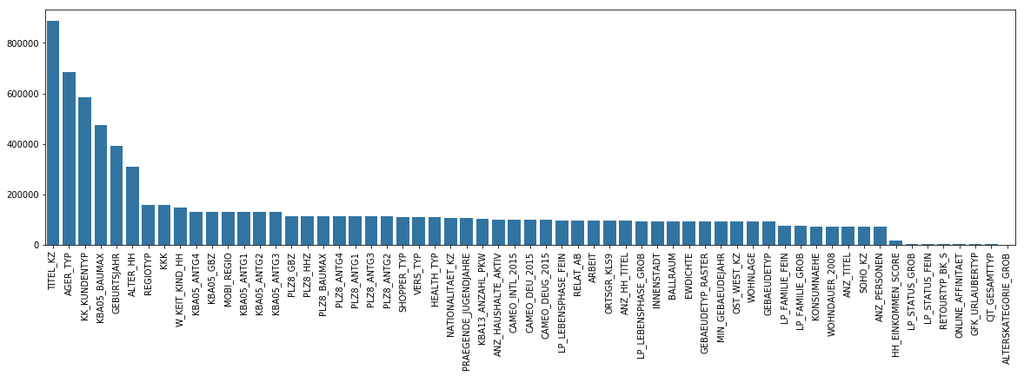

```python
# Perform an assessment of how much missing data there is in each column of the dataset.
mv = azdias.isna().sum()
mv = mv[mv > 0]
mv = mv.sort_values(ascending=False)
fig, ax = plt.subplots(figsize=[20, 5])
sns.barplot(ax=ax, x=list(mv.index), y=mv, color=sns.color_palette()[0])
plt.xticks(rotation=90)
plt.show()
```

```python
# Investigate patterns in the amount of missing data in each column.
vars_no_mv = [col for col in azdias.columns if col not in mv]
mv_vars = azdias.drop(columns=vars_no_mv)
mv_corr = mv_vars.corr()
mv_corr.head()
```

|  | AGER_TYP | ALTERSKATEGORIE_GROB | CJT_GESAMTTYP | GEBURTSJAHR | GFK_URLAUBERTYP | HEALTH_TYP | LP_LEBENSPHASE_FEIN | LP_LEBENSPHASE_GROB | LP_FAMILIE_FEIN | LP_FAMILIE_GROB | ... | PLZ8_ANTG1 | PLZ8_ANTG2 | PLZ8_ANTG3 | PLZ8_ANTG4 | PLZ8_BAUMAX | PLZ8_HHZ | PLZ8_GBZ | ARBEIT | ORTSGR_KLS9 | RELAT_AB |
| --- | --- | --- | --- | --- | --- | --- | --- | --- | --- | --- | --- | --- | --- | --- | --- | --- | --- | --- | --- | --- | --- |
| AGER_TYP | 1.000000 | -0.371805 | 0.060196 | 0.060389 | 0.060186 | 0.204686 | -0.069289 | -0.059852 | -0.044831 | -0.044481 | ... | -0.120315 | 0.099386 | 0.123365 | 0.109080 | 0.096508 | 0.042794 | -0.060875 | 0.058592 | 0.112153 | 0.057398 |
| ALTERSKATEGORIE_GROB | -0.371805 | 1.000000 | -0.287232 | -0.633205 | -0.131809 | -0.233667 | 0.085698 | 0.053174 | -0.049436 | -0.048765 | ... | 0.061378 | -0.044124 | -0.065680 | -0.065197 | -0.067072 | -0.030794 | 0.034979 | -0.034084 | -0.064829 | -0.024993 |
| CJT_GESAMTTYP | 0.060196 | -0.287232 | 1.000000 | 0.338822 | 0.009363 | 0.117291 | 0.037083 | 0.052411 | 0.084924 | 0.088865 | ... | -0.029733 | 0.031113 | 0.039168 | 0.037845 | 0.037422 | 0.019464 | -0.018341 | 0.021856 | 0.076323 | 0.024888 |
| GEBURTSJAHR | 0.060389 | -0.633205 | 0.338822 | 1.000000 | 0.139847 | 0.169254 | -0.051617 | -0.017197 | 0.109812 | 0.113454 | ... | -0.036817 | 0.027019 | 0.036860 | 0.040735 | 0.047966 | 0.019948 | -0.019243 | -0.002229 | 0.035689 | 0.010592 |
| GFK_URLAUBERTYP | 0.060186 | -0.131809 | 0.009363 | 0.139847 | 1.000000 | 0.064466 | -0.126759 | -0.112486 | -0.073301 | -0.074316 | ... | -0.105340 | 0.055839 | 0.105911 | 0.109085 | 0.098907 | 0.030986 | -0.071555 | 0.068319 | 0.068732 | 0.054780 |

5 rows × 57 columns

```python
# highly correlated missingness --> arbitrarily defining "high" as corr > 0.4
high_mv_corr = []
for i in range(0, len(mv_corr.index)):
    for j in range(i+1, len(mv_corr.columns)):
        if mv_corr.iloc[i, j] > 0.4:
            high_mv_corr.append((mv_corr.index[i], mv_corr.columns[j]))
high_mv_corr
```

```
[('GEBURTSJAHR', 'PRAEGENDE_JUGENDJAHRE'),
 ('GEBURTSJAHR', 'ALTER_HH'),
 ('GEBURTSJAHR', 'ONLINE_AFFINITAET'),
 ('LP_LEBENSPHASE_FEIN', 'LP_LEBENSPHASE_GROB'),
 ('LP_LEBENSPHASE_FEIN', 'LP_FAMILIE_FEIN'),
 ('LP_LEBENSPHASE_FEIN', 'LP_FAMILIE_GROB'),
 ('LP_LEBENSPHASE_FEIN', 'LP_STATUS_FEIN'),
 ('LP_LEBENSPHASE_FEIN', 'LP_STATUS_GROB'),
 ('LP_LEBENSPHASE_FEIN', 'ANZ_PERSONEN'),
 ('LP_LEBENSPHASE_GROB', 'LP_FAMILIE_FEIN'),
 ('LP_LEBENSPHASE_GROB', 'LP_FAMILIE_GROB'),
 ('LP_LEBENSPHASE_GROB', 'LP_STATUS_FEIN'),
 ('LP_LEBENSPHASE_GROB', 'LP_STATUS_GROB'),
 ('LP_LEBENSPHASE_GROB', 'ANZ_PERSONEN'),
 ('LP_FAMILIE_FEIN', 'LP_FAMILIE_GROB'),
 ('LP_FAMILIE_FEIN', 'ANZ_PERSONEN'),
 ('LP_FAMILIE_GROB', 'ANZ_PERSONEN'),
 ('LP_FAMILIE_GROB', 'ONLINE_AFFINITAET'),
 ('LP_STATUS_FEIN', 'LP_STATUS_GROB'),
 ('LP_STATUS_FEIN', 'KBA05_ANTG1'),
 ('LP_STATUS_FEIN', 'KBA05_GBZ'),
 ('LP_STATUS_FEIN', 'MOBI_REGIO'),
 ('LP_STATUS_FEIN', 'PLZ8_ANTG1'),
 ('LP_STATUS_GROB', 'KBA05_ANTG1'),
 ('LP_STATUS_GROB', 'KBA05_GBZ'),
 ('LP_STATUS_GROB', 'MOBI_REGIO'),
 ('LP_STATUS_GROB', 'PLZ8_ANTG1'),
 ('PRAEGENDE_JUGENDJAHRE', 'ALTER_HH'),
 ('PRAEGENDE_JUGENDJAHRE', 'ONLINE_AFFINITAET'),
 ('ALTER_HH', 'ONLINE_AFFINITAET'),
 ('HH_EINKOMMEN_SCORE', 'KBA05_BAUMAX'),
 ('HH_EINKOMMEN_SCORE', 'PLZ8_ANTG3'),
 ('ANZ_HAUSHALTE_AKTIV', 'KBA05_ANTG4'),
 ('ANZ_HAUSHALTE_AKTIV', 'KBA05_BAUMAX'),
 ('KONSUMNAEHE', 'GEBAEUDETYP_RASTER'),
 ('KONSUMNAEHE', 'MOBI_REGIO'),
 ('KONSUMNAEHE', 'PLZ8_ANTG1'),
 ('KBA05_ANTG1', 'KBA05_GBZ'),
 ('KBA05_ANTG1', 'MOBI_REGIO'),
 ('KBA05_ANTG1', 'PLZ8_ANTG1'),
```

[output cut: 25 more lines]

```
 ('PLZ8_ANTG1', 'PLZ8_GBZ'),
 ('PLZ8_ANTG2', 'PLZ8_ANTG3'),
 ('PLZ8_ANTG2', 'PLZ8_BAUMAX'),
 ('PLZ8_ANTG3', 'PLZ8_ANTG4'),
 ('PLZ8_ANTG3', 'PLZ8_BAUMAX'),
 ('PLZ8_ANTG3', 'ARBEIT'),
 ('PLZ8_ANTG3', 'ORTSGR_KLS9'),
 ('PLZ8_ANTG3', 'RELAT_AB'),
 ('PLZ8_ANTG4', 'PLZ8_BAUMAX'),
 ('PLZ8_ANTG4', 'ORTSGR_KLS9'),
 ('PLZ8_BAUMAX', 'ORTSGR_KLS9'),
 ('PLZ8_HHZ', 'PLZ8_GBZ'),
 ('ARBEIT', 'ORTSGR_KLS9'),
 ('ARBEIT', 'RELAT_AB'),
 ('ORTSGR_KLS9', 'RELAT_AB')]
```

```python
# Remove the outlier columns from the dataset. (You'll perform other data
# engineering tasks such as re-encoding and imputation later.)

# dropping variables with more than 20% values missing
print((mv/len(azdias.index))[0:10])
mv_outliers = mv[mv/len(azdias.index) > 0.2]
data = azdias.drop(columns=mv_outliers.index)
```

```
TITEL_KZ          0.997576
AGER_TYP          0.769554
KK_KUNDENTYP      0.655967
KBA05_BAUMAX      0.534687
GEBURTSJAHR       0.440203
ALTER_HH          0.348137
REGIOTYP          0.177357
KKK               0.177357
W_KEIT_KIND_HH    0.166051
KBA05_ANTG4       0.149597
dtype: float64
```

#### Discussion 1.1.2: Assess Missing Data in Each Column

Most observations have missing values in some variables. This is normal for administrative and survey-based data sets, but some variables are outliers in their degree of missingness. Six variables have missing values in between ~35% and 99.8% of the observations, while other variables are missing values for less than 18% of the sample.

The six variables that are outliers with respect to their rate of missingness are: Academic title flag (e.g. Dr., Prof.): 99.76% Best-ager typology (e.g. "passive elderly", "cultural elderly"): 76.96% Consumer pattern over past 12 months (e.g. "regular customer", "stray customer"): 65.6% Most common building type within the microcell (categorical mean home size or business): 53.47% Year of birth: 44.02% Birthdate of head of household (ordinal, 5-year interval categories): 34.81%

For most variables, we can impute missing values using a "multiple imputation" procedure such as Multivariate Normal (MVN) imputation or Multiple Imputation using Chained Equations (MICE). These methods use known variable values to predict missing variable values. Use of these methods relaxes the Missing Completely at Random (MCAR) assumption, allowing us to reduce bias when data is Missing at Random (MAR). The performance of multiple imputation will depend on the degree of correlation between the probability that a value is missing and the non-missing values of other variables among other observations--we need to be able to predict when values are missing. If data is Missing Not at Random (MNAR), there is no known solution to bias due to patterns in missing data.

Multiple imputation methods include other assumptions. For example, MVN imputation assumes variables are distributed multivariate normal. Still, MVN has been show to be generally robust to deviations from normality (I do not have a source off-hand but this is common knowledge among econometricians). I've heard a common rule of thumb that multiple imputation methods work well with more than 50% of values missing for a variable, though I do not have a source at hand to cite and a simulation experiment is outside the scope of the current project. The proportion of data that is missing should only affect the performance of the procedures to the extent that the non-missing information is sufficient to predict the missing information.

A correlation matrix suggests some variables are more or less likely to be missing when others are missing. This suggests missingness is likely not MCAR. I was unable to find an existing python implementation of a formal statistical test, such as Little's MCAR test, to assess the MCAR assumption. Implementation of the test is outside the current scope of this project. Still, given the degree of correlation in missingness between some variables and the size of our sample, it appears the MCAR assumption is unreliable. Such a correlation matrix does not imply multiple imputation will perform well, because the matrix does not indicate whether actual variable values are able to predict when values in other variables are missing. Unfortunately, MAR is not a testable assumption because such a test would require knowledge of the nature of the missing value patterns that can't be obtained from data without external information or knowledge of the missing values themselves.

I have dropped variables that are missing values for more than 20% of observations, and will impute missing values for the remaining variables.

#### Step 1.1.3: Assess Missing Data in Each Row

Now, you'll perform a similar assessment for the rows of the dataset. How much data is missing in each row? As with the columns, you should see some groups of points that have a very different numbers of missing values. Divide the data into two subsets: one for data points that are above some threshold for missing values, and a second subset for points below that threshold.

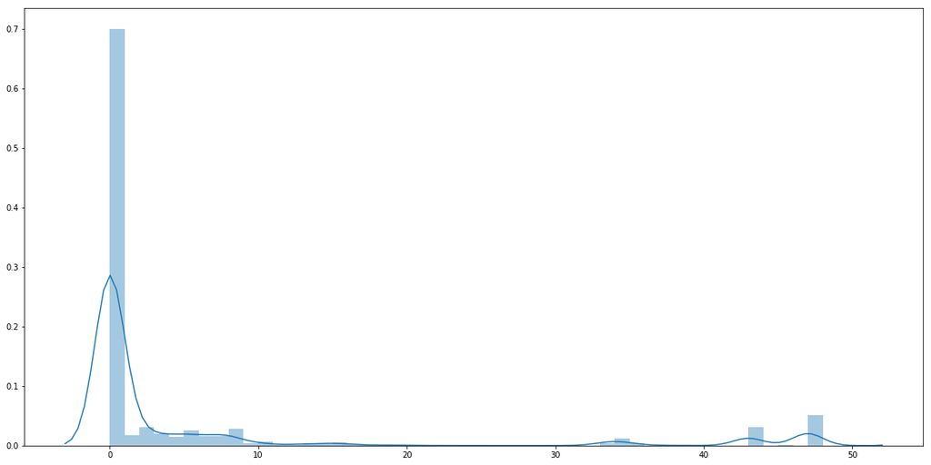

```python
# How much data is missing in each row of the dataset?
mv_count = data.isna().sum(axis=1) # note that columns with >20% missing have already been dropped
fig = plt.figure(figsize=(20, 10))
sns.distplot(mv_count, kde_kws={'bw': 1}, bins=range(0, mv_count.max()+1))
```

```python
# Write code to divide the data into two subsets based on the number of missing
# values in each row.
mv_idx = mv_count[mv_count > 25].index
keep_idx = mv_count[mv_count <= 25].index

mv_data = data.drop(index=keep_idx)
data = data.drop(index=mv_idx)
print(mv_data.shape)
print(data.shape)
```

```
(93260, 79)
(797961, 79)
```

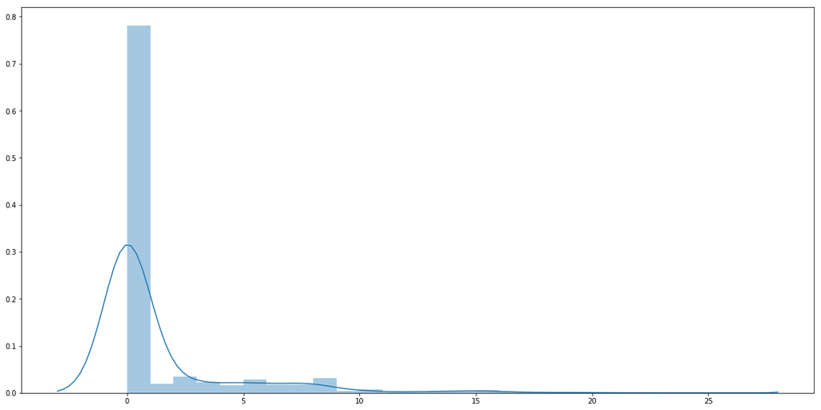

```python
# How much data is missing in each row of the dataset? -> Sample I am keeping
kept_mv_count = data.isna().sum(axis=1) # note that columns with >20% missing have already been dropped
fig = plt.figure(figsize=(20, 10))
sns.distplot(kept_mv_count, kde_kws={'bw': 1}, bins=range(0, kept_mv_count.max()+1))
```

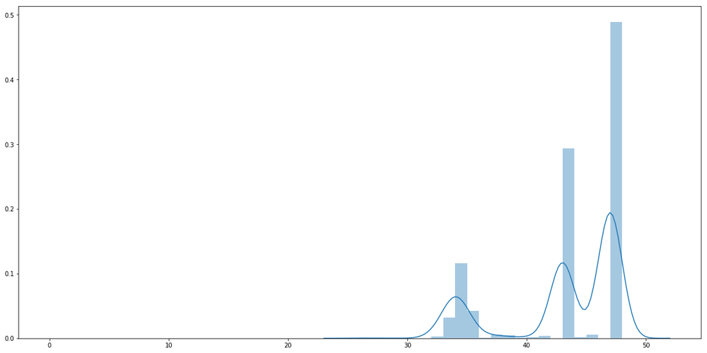

```python
# How much data is missing in each row of the dataset? -> Sample I am dropping
dropped_mv_count = mv_data.isna().sum(axis=1) # note that columns with >50% missing have already been dropped
fig = plt.figure(figsize=(20, 10))
sns.distplot(dropped_mv_count, kde_kws={'bw': 1}, bins=range(0, dropped_mv_count.max()+1))
```

```python
# get list of columns with few missing values so I can plot them in next cells (low mv sample)
mv_low = data.isna().sum()
no_mv_low = mv_low[mv_low/len(data.index) < 0.05].index
print(no_mv_low)
```

```
Index(['ALTERSKATEGORIE_GROB', 'ANREDE_KZ', 'CJT_GESAMTTYP',
       'FINANZ_MINIMALIST', 'FINANZ_SPARER', 'FINANZ_VORSORGER',
       'FINANZ_ANLEGER', 'FINANZ_UNAUFFAELLIGER', 'FINANZ_HAUSBAUER',
       'FINANZTYP', 'GFK_URLAUBERTYP', 'GREEN_AVANTGARDE', 'HEALTH_TYP',
       'LP_FAMILIE_FEIN', 'LP_FAMILIE_GROB', 'LP_STATUS_FEIN',
       'LP_STATUS_GROB', 'NATIONALITAET_KZ', 'PRAEGENDE_JUGENDJAHRE',
       'RETOURTYP_BK_S', 'SEMIO_SOZ', 'SEMIO_FAM', 'SEMIO_REL', 'SEMIO_MAT',
       'SEMIO_VERT', 'SEMIO_LUST', 'SEMIO_ERL', 'SEMIO_KULT', 'SEMIO_RAT',
       'SEMIO_KRIT', 'SEMIO_DOM', 'SEMIO_KAEM', 'SEMIO_PFLICHT', 'SEMIO_TRADV',
       'SHOPPER_TYP', 'SOHO_KZ', 'VERS_TYP', 'ZABEOTYP', 'ANZ_PERSONEN',
       'ANZ_TITEL', 'HH_EINKOMMEN_SCORE', 'WOHNDAUER_2008',
       'ANZ_HAUSHALTE_AKTIV', 'ANZ_HH_TITEL', 'GEBAEUDETYP', 'KONSUMNAEHE',
       'MIN_GEBAEUDEJAHR', 'OST_WEST_KZ', 'WOHNLAGE', 'CAMEO_DEUG_2015',
       'CAMEO_DEU_2015', 'CAMEO_INTL_2015', 'BALLRAUM', 'EWDICHTE',
       'INNENSTADT', 'GEBAEUDETYP_RASTER', 'ONLINE_AFFINITAET',
       'KBA13_ANZAHL_PKW', 'PLZ8_ANTG1', 'PLZ8_ANTG2', 'PLZ8_ANTG3',
       'PLZ8_ANTG4', 'PLZ8_BAUMAX', 'PLZ8_HHZ', 'PLZ8_GBZ', 'ARBEIT',
       'ORTSGR_KLS9', 'RELAT_AB'],
      dtype='object')
```

```python
# get list of columns with few missing values so I can plot them in next cells (high mv sample)
mv_high = mv_data.isna().sum()
no_mv_high = mv_high[mv_high/len(mv_data.index) < 0.05].index
print(no_mv_high)
```

```
Index(['ALTERSKATEGORIE_GROB', 'ANREDE_KZ', 'CJT_GESAMTTYP',
       'FINANZ_MINIMALIST', 'FINANZ_SPARER', 'FINANZ_VORSORGER',
       'FINANZ_ANLEGER', 'FINANZ_UNAUFFAELLIGER', 'FINANZ_HAUSBAUER',
       'FINANZTYP', 'GFK_URLAUBERTYP', 'GREEN_AVANTGARDE', 'LP_STATUS_FEIN',
       'LP_STATUS_GROB', 'RETOURTYP_BK_S', 'SEMIO_SOZ', 'SEMIO_FAM',
       'SEMIO_REL', 'SEMIO_MAT', 'SEMIO_VERT', 'SEMIO_LUST', 'SEMIO_ERL',
       'SEMIO_KULT', 'SEMIO_RAT', 'SEMIO_KRIT', 'SEMIO_DOM', 'SEMIO_KAEM',
       'SEMIO_PFLICHT', 'SEMIO_TRADV', 'ZABEOTYP', 'ONLINE_AFFINITAET'],
      dtype='object')
```

```python
# I wrote these functions for continuous features before I realized there are very few continuous features
# These are untested and may require debugging

def standardize(x):
    return (x - x.mean()) / x.std()


def compare_continuous_distributions(x, y, varname):
    # standardize data
    x = standardize(x[varname])
    y = standardize(y[varname])
    # standardize x-axis
    max_bin = max(x.max(), y.max())
    bin_edges = np.arange(0, max_bin + 1, 1)
    # create axis
    ax = plt.subplot()
    # graph distributions
    sns.distplot(x, ax=ax, bins=bin_edges, hist=False, color=sns.color_palette()[0], label='X')
    sns.distplot(y, ax=ax, bins=bin_edges, hist=False, color=sns.color_palette()[0], label='Y')
    ax.set_title('Standardized ' + varname + ' Distributions')

    return ax


def qq_plot(x, y, varname):
    # standardize data
    x = standardize(x[varname])
    y = standardize(y[varname])
    # create axis
    ax = plt.subplot()
    # scatter x vals vs. y vals
    sns.regplot(x=x, y=y, ax=ax, fit_reg=False)
    # add 45 degree line
    line = np.linspace(ax.get_xlim()[0], ax.get_xlim([1]))
    ax.plot(line, line, fmt='k--')
    # add title
    ax.set_title('QQ plot for ' + varname)

    return ax
```

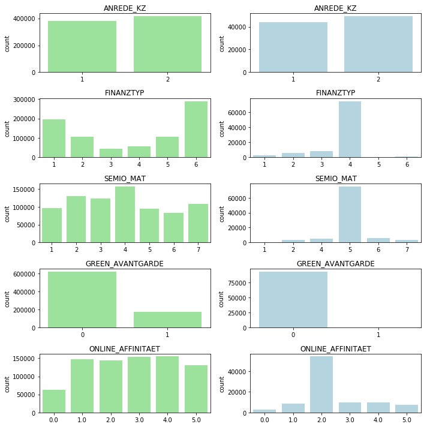

```python
# Compare the distribution of values for at least five columns where there are
# no or few missing values, between the two subsets.

# plotting the following variables that have less than 5% missing values:
# ANREDE_KZ -> Gender (binary indicator)
# FINANZTYP -> Most descriptive "financial type" (categorical, e.g. "investor", "money-saver")
# SEMIO_MAT ->  Personality typology, materialistic (ordered, "lowest" to "highest")
# GREEN_AVANTGARDE -> Membership in environmental sustainability as part of youth (binary indicator)
# ONLINE_AFFINITAET -> Online affinity (ordered, "none" to "highest")

varlist = ['ANREDE_KZ', 'FINANZTYP', 'SEMIO_MAT', 'GREEN_AVANTGARDE', 'ONLINE_AFFINITAET']

# Note: compare the shapes of the distributions, but note the different y-axis scales
fig, ax = plt.subplots(nrows=5, ncols=2, figsize=[10, 10])
for i in range(0, ax.shape[0]):
    # graph distributions
    plt.sca(ax[i,0])
    sns.countplot(data[varlist[i]], color='lightgreen')
    plt.title(varlist[i])
    plt.xlabel('')
    plt.sca(ax[i,1])
    sns.countplot(mv_data[varlist[i]], color='lightblue')
    plt.title(varlist[i])
    plt.xlabel('')
plt.tight_layout()
plt.show()
```

#### Discussion 1.1.3: Assess Missing Data in Each Row

The sample distribution of missing data frequency is bi- or multi-modal, with some discrete spikes in value. This is not strange given the nature of the data. Some features in the data set are clustered. For example, there are several features about personality traits. These features are related to one another in such a way that we can expect some level of dependence in the presence of their values--when one is missing, it is likely that all are missing.

Because very few observations had between 20 and 30 missing values, creating a clear bi-modality around that interval, I dropped observations with more than 25 missing values. This approach is practical, but will institute bias because the observations are dropped systematically. This becomes obvious when we compare the sample with few missing values to the sample with high missing values across variables for which neither sample has a high rate of missing values. The distributions of these variables differ substantially between the two samples.

Unfortunately, some important variables have high rates of missing values in the subsample of observations that has been dropped. Some examples of potentially-important variables that cannot be compared include:

[output not shown]

We are making a decision of which type of bias to keep: bias from dropping important variables, bias from systematically dropping observations, or bias from imputing missing values when data is MNAR. We would certainly cause substantial bias by not conditioning on multiple important variables. While we can make a case that the data is MAR, we cannot avoid making untestable assumptions about the nature of the missing data. Because entire clusters of information (e.g. personality-related questions) tend to be missing together, it is likely that the mechanism causing the missingness is an unobserved process.

Still, if the data are even partially MAR we will benefit from use of multiple imputation techniques--listwise deletion is almost always worse in terms of statistical bias and efficiency. Were the instructions for this project different, I would strongly consider keeping all of the observations in the sample and using multiple imputation to hopefully achieve the least-biased estimates.

### Step 1.2: Select and Re-Encode Features

```python
# How many features are there of each data type?
feat_info['type'].value_counts()
```

```
ordinal        49
categorical    21
mixed           7
numeric         7
interval        1
Name: type, dtype: int64
```

#### Step 1.2.1: Re-Encode Categorical Features

For categorical data, you would ordinarily need to encode the levels as dummy variables. Depending on the number of categories, perform one of the following:

- For binary (two-level) categoricals that take numeric values, you can keep them without needing to do anything.
- There is one binary variable that takes on non-numeric values. For this one, you need to re-encode the values as numbers or create a dummy variable.
- For multi-level categoricals (three or more values), you can choose to encode the values using multiple dummy variables (e.g. via [OneHotEncoder](http://scikit-learn.org/stable/modules/generated/sklearn.preprocessing.OneHotEncoder.html)), or (to keep things straightforward) just drop them from the analysis. As always, document your choices in the Discussion section.

```python
# Assess categorical variables: which are binary, which are multi-level, and
# which one needs to be re-encoded?
cat_vars = feat_info[feat_info['type']=='categorical']['attribute']
cat_vars = cat_vars[~cat_vars.isin(mv_outliers.index)] # already dropped these columns
cat_vars = cat_vars[~cat_vars.isin(['FINANZTYP', 'LP_FAMILIE_FEIN', 'GFK_URLAUBERTYP', 'LP_STATUS_FEIN', 'CAMEO_DEU_2015'])] # dropping these
cat_vars = cat_vars[~cat_vars.isin(['GREEN_AVANTGARDE', 'SOHO_KZ'])] # already indicators
print(cat_vars)
data[cat_vars].dtypes
```

```
2            ANREDE_KZ
3        CJT_GESAMTTYP
18     LP_FAMILIE_GROB
20      LP_STATUS_GROB
21    NATIONALITAET_KZ
38         SHOPPER_TYP
41            VERS_TYP
42            ZABEOTYP
52         GEBAEUDETYP
55         OST_WEST_KZ
57     CAMEO_DEUG_2015
Name: attribute, dtype: object
```

```
ANREDE_KZ             int64
CJT_GESAMTTYP       float64
LP_FAMILIE_GROB     float64
LP_STATUS_GROB      float64
NATIONALITAET_KZ    float64
SHOPPER_TYP         float64
VERS_TYP            float64
ZABEOTYP              int64
GEBAEUDETYP         float64
OST_WEST_KZ          object
CAMEO_DEUG_2015      object
dtype: object
```

```python
# Re-encode categorical variable(s) to be kept in the analysis.
for var in cat_vars:
    nan_idx = pd.isnull(data[var]).nonzero()[0]
    df = pd.get_dummies(data[var], prefix=var, drop_first=True)
    df.iloc[nan_idx,:] = np.nan
    data = data.drop(columns=var)
    data = data.join(df)

# dropping categorical variables that don't offer much additional information
data = data.drop(columns=['FINANZTYP', 'LP_FAMILIE_FEIN', 'GFK_URLAUBERTYP', 'CAMEO_DEU_2015', 'LP_STATUS_FEIN'])
```

```python
print(list(data.columns))
```

```
['ALTERSKATEGORIE_GROB', 'FINANZ_MINIMALIST', 'FINANZ_SPARER', 'FINANZ_VORSORGER', 'FINANZ_ANLEGER', 'FINANZ_UNAUFFAELLIGER', 'FINANZ_HAUSBAUER', 'GREEN_AVANTGARDE', 'HEALTH_TYP', 'LP_LEBENSPHASE_FEIN', 'LP_LEBENSPHASE_GROB', 'PRAEGENDE_JUGENDJAHRE', 'RETOURTYP_BK_S', 'SEMIO_SOZ', 'SEMIO_FAM', 'SEMI…
```

#### Discussion 1.2.1: Re-Encode Categorical Features

I dropped CAMEO_DEU_2015, FINANZTYP, LP_FAMILIE_FEIN, and LP_STATUS_FEIN, because they are summarizations or rougher versions of other available variables. I dropped GFK_URLAUBERTYP, which represent vacationer type, because it produces 12 dummy variables and I expect it will offer only marginal additional information after we include variables like social status, family type, and life stage.

I kept the remaining categorical features. By keeping all of these categorical features, I will have more information available to use in prinicipal components analysis. Dimensionality reduction will occur at that step.

I recoded all categorical variables as a series of indicator/dummy variables.

Note that treating ordinal variables as continuous is highly frowned upon in the research community, which is where my background lies. We could instead condition on all of the categories. For exmaple, nobody would take seriously a regression analysis that treated educational attainment as an ordinal variable (e.g. HS degree, BA, MA, PhD).

#### Step 1.2.2: Engineer Mixed-Type Features

There are a handful of features that are marked as "mixed" in the feature summary that require special treatment in order to be included in the analysis. There are two in particular that deserve attention; the handling of the rest are up to your own choices:

- "PRAEGENDE_JUGENDJAHRE" combines information on three dimensions: generation by decade, movement (mainstream vs. avantgarde), and nation (east vs. west). While there aren't enough levels to disentangle east from west, you should create two new variables to capture the other two dimensions: an interval-type variable for decade, and a binary variable for movement.
- "CAMEO_INTL_2015" combines information on two axes: wealth and life stage. Break up the two-digit codes by their 'tens'-place and 'ones'-place digits into two new ordinal variables (which, for the purposes of this project, is equivalent to just treating them as their raw numeric values).
- If you decide to keep or engineer new features around the other mixed-type features, make sure you note your steps in the Discussion section.

Be sure to check `Data_Dictionary.md` for the details needed to finish these tasks.

```python
mixed_vars = feat_info[feat_info['type']=='mixed']['attribute']
mixed_vars = mixed_vars[~mixed_vars.isin(mv_outliers.index)]
print(mixed_vars)
```

```
15      LP_LEBENSPHASE_FEIN
16      LP_LEBENSPHASE_GROB
22    PRAEGENDE_JUGENDJAHRE
56                 WOHNLAGE
59          CAMEO_INTL_2015
79              PLZ8_BAUMAX
Name: attribute, dtype: object
```

```python
# Investigate "PRAEGENDE_JUGENDJAHRE" and engineer two new variables.
print('\n' + 'Unique values of PRAEGENDE_JUGENDJAHRE:')
print(data['PRAEGENDE_JUGENDJAHRE'].unique())

# possible values of PRAEGENDE_JUGENDJAHRE
# Dominating movement of person's youth (avantgarde vs. mainstream; east vs. west)
'''
-  1: 40s - war years (Mainstream, E+W)
-  2: 40s - reconstruction years (Avantgarde, E+W)
-  3: 50s - economic miracle (Mainstream, E+W)
-  4: 50s - milk bar / Individualisation (Avantgarde, E+W)
-  5: 60s - economic miracle (Mainstream, E+W)
-  6: 60s - generation 68 / student protestors (Avantgarde, W)
-  7: 60s - opponents to the building of the Wall (Avantgarde, E)
-  8: 70s - family orientation (Mainstream, E+W)
-  9: 70s - peace movement (Avantgarde, E+W)
- 10: 80s - Generation Golf (Mainstream, W)
- 11: 80s - ecological awareness (Avantgarde, W)
- 12: 80s - FDJ / communist party youth organisation (Mainstream, E)
- 13: 80s - Swords into ploughshares (Avantgarde, E)
- 14: 90s - digital media kids (Mainstream, E+W)
- 15: 90s - ecological awareness (Avantgarde, E+W)
'''

# generation
#data['generation_40'] = data['PRAEGENDE_JUGENDJAHRE'].isin([1., 2.]).astype(int) # 40s
data['generation_50'] = data['PRAEGENDE_JUGENDJAHRE'].isin([3., 4.]).astype(int) # 50s
data['generation_60'] = data['PRAEGENDE_JUGENDJAHRE'].isin([5., 6., 7.]).astype(int) # 60s
data['generation_70'] = data['PRAEGENDE_JUGENDJAHRE'].isin([8., 9.]).astype(int) # 70s
data['generation_80'] = data['PRAEGENDE_JUGENDJAHRE'].isin([10., 11., 12.]).astype(int) # 80s
data['generation_90'] = data['PRAEGENDE_JUGENDJAHRE'].isin([13., 14.]).astype(int) # 90s

# mainstream or counterculture
#data['mainstream_youth'] = data['PRAEGENDE_JUGENDJAHRE'].isin([1., 3., 5., 8., 10., 12., 14.]).astype(int) # mainstream
data['avantgarde_youth'] = data['PRAEGENDE_JUGENDJAHRE'].isin([2., 4., 6., 7., 9., 11., 13., 15.]).astype(int) # avantgarde

# fix values that are actually missing but became False during dummy creation
nan_idx = pd.isnull(data['PRAEGENDE_JUGENDJAHRE']).nonzero()[0]
for var in ['generation_50', 'generation_60', 'generation_70', 'generation_80', 'generation_90', 'avantgarde_youth']:
    data.iloc[nan_idx, data.columns.get_loc(var)] = np.nan
data = data.drop(columns='PRAEGENDE_JUGENDJAHRE')

print('\n' + 'Make sure columns were created:')
print(list(data.columns))

print('\n' + 'Make sure missing values are preserved:')
print(data['generation_50'].isna().describe())
```

```
Unique values of PRAEGENDE_JUGENDJAHRE:
[14. 15.  8.  3. 10. 11.  5.  9.  6.  4. nan  2.  1. 12. 13.  7.]

Make sure columns were created:
['ALTERSKATEGORIE_GROB', 'FINANZ_MINIMALIST', 'FINANZ_SPARER', 'FINANZ_VORSORGER', 'FINANZ_ANLEGER', 'FINANZ_UNAUFFAELLIGER', 'FINANZ_HAUSBAUER', 'GREEN_AVANTGARDE', 'HEALTH_TYP', 'LP_LEBENSPHASE_FEIN', 'LP_LEBENSPHASE_GROB', 'RETOURTYP_BK_S', 'SEMIO_SOZ', 'SEMIO_FAM', 'SEMIO_REL', 'SEMIO_MAT', 'SEM…

Make sure missing values are preserved:
count     797961
unique         2
top        False
freq      769252
Name: generation_50, dtype: object
```

```python
# Investigate "CAMEO_INTL_2015" and engineer two new variables.
print('\n' + 'Unique values of CAMEO_INTL_2015:')
print(data['CAMEO_INTL_2015'].unique())

# possible values for CAMEO_INTL_2015
# German CAMEO: Wealth / Life Stage Typology, mapped to international code
'''
- 11: Wealthy Households - Pre-Family Couples & Singles
- 12: Wealthy Households - Young Couples With Children
- 13: Wealthy Households - Families With School Age Children
- 14: Wealthy Households - Older Families &  Mature Couples
- 15: Wealthy Households - Elders In Retirement
- 21: Prosperous Households - Pre-Family Couples & Singles
- 22: Prosperous Households - Young Couples With Children
- 23: Prosperous Households - Families With School Age Children
- 24: Prosperous Households - Older Families & Mature Couples
- 25: Prosperous Households - Elders In Retirement
- 31: Comfortable Households - Pre-Family Couples & Singles
- 32: Comfortable Households - Young Couples With Children
- 33: Comfortable Households - Families With School Age Children
- 34: Comfortable Households - Older Families & Mature Couples
- 35: Comfortable Households - Elders In Retirement
- 41: Less Affluent Households - Pre-Family Couples & Singles
- 42: Less Affluent Households - Young Couples With Children
- 43: Less Affluent Households - Families With School Age Children
- 44: Less Affluent Households - Older Families & Mature Couples
- 45: Less Affluent Households - Elders In Retirement
- 51: Poorer Households - Pre-Family Couples & Singles
- 52: Poorer Households - Young Couples With Children
- 53: Poorer Households - Families With School Age Children
- 54: Poorer Households - Older Families & Mature Couples
- 55: Poorer Households - Elders In Retirement
'''

# SES
data['SES'] = data['CAMEO_INTL_2015'].replace(['11', '12', '13', '14', '15',
                                               '21', '22', '23', '24', '25',
                                               '31', '32', '33', '34', '35',
                                               '41', '42', '43', '44', '45',
                                               '51', '52', '53', '54', '55'],
                                               [4, 4, 4, 4, 4,
                                                3, 3, 3, 3, 3,
                                                2, 2, 2, 2, 2,
                                                1, 1, 1, 1, 1,
                                                0, 0, 0, 0, 0])

# Life Stage
data['life_stage_type'] = data['CAMEO_INTL_2015'].replace(['11', '12', '13', '14', '15',
                                                   '21', '22', '23', '24', '25',
                                                   '31', '32', '33', '34', '35',
                                                   '41', '42', '43', '44', '45',
                                                   '51', '52', '53', '54', '55'],
                                                   [0, 1, 2, 3, 4,
                                                    0, 1, 2, 3, 4,
                                                    0, 1, 2, 3, 4,
                                                    0, 1, 2, 3, 4,
                                                    0, 1, 2, 3, 4])

data = data.drop(columns='CAMEO_INTL_2015')
```

```
Unique values of CAMEO_INTL_2015:
['51' '24' '12' '43' '54' '22' '14' '13' '15' '33' '41' '34' '55' nan '25'
 '23' '31' '52' '35' '45' '44' '32']
```

```python
# Remaining mixed-type variables
# drop LP_LEBENSPHASE_FEIN in favor of rougher variable
# drop PLZ8_BAUMAX to reduce dimensionality--this variable seems relatively unimportant
data = data.drop(columns=['LP_LEBENSPHASE_FEIN', 'PLZ8_BAUMAX'])

# turning these mixed vars into dummy variables
# life stage, neighborhood quality or rural flag
mixed_to_dummies = ['LP_LEBENSPHASE_GROB', 'WOHNLAGE']

# Re-encode mixed-categorical variable(s) to be kept in the analysis.
for var in mixed_to_dummies:
    nan_idx = pd.isnull(data[var]).nonzero()[0]
    df = pd.get_dummies(data[var], prefix=var, drop_first=True)
    df.iloc[nan_idx,:] = np.nan
    data = data.drop(columns=var)
    data = data.join(df)
```

#### Discussion 1.2.2: Engineer Mixed-Type Features

I dropped LP_LEBENSPHASE_FEIN, which categorizes the "life stage" of people in the dataset at a fine level. I retained a rougher version of that variable, LP_LEBENSPHASE_GROB. The decision was made because the fine version of the variable has a large number of categories (40), and it seems reasonable that the information can largely be captured in the rougher 12-category variable. This allows us to cut a full 28 dummy variables.

#### Step 1.2.3: Complete Feature Selection

In order to finish this step up, you need to make sure that your data frame now only has the columns that you want to keep. To summarize, the dataframe should consist of the following:

- All numeric, interval, and ordinal type columns from the original dataset.
- Binary categorical features (all numerically-encoded).
- Engineered features from other multi-level categorical features and mixed features.

```python
# If there are other re-engineering tasks you need to perform, make sure you
# take care of them here. (Dealing with missing data will come in step 2.1.)
list(data.columns)
```

```
['ALTERSKATEGORIE_GROB',
 'FINANZ_MINIMALIST',
 'FINANZ_SPARER',
 'FINANZ_VORSORGER',
 'FINANZ_ANLEGER',
 'FINANZ_UNAUFFAELLIGER',
 'FINANZ_HAUSBAUER',
 'GREEN_AVANTGARDE',
 'HEALTH_TYP',
 'RETOURTYP_BK_S',
 'SEMIO_SOZ',
 'SEMIO_FAM',
 'SEMIO_REL',
 'SEMIO_MAT',
 'SEMIO_VERT',
 'SEMIO_LUST',
 'SEMIO_ERL',
 'SEMIO_KULT',
 'SEMIO_RAT',
 'SEMIO_KRIT',
 'SEMIO_DOM',
 'SEMIO_KAEM',
 'SEMIO_PFLICHT',
 'SEMIO_TRADV',
 'SOHO_KZ',
 'ANZ_PERSONEN',
 'ANZ_TITEL',
 'HH_EINKOMMEN_SCORE',
 'W_KEIT_KIND_HH',
 'WOHNDAUER_2008',
 'ANZ_HAUSHALTE_AKTIV',
 'ANZ_HH_TITEL',
 'KONSUMNAEHE',
 'MIN_GEBAEUDEJAHR',
 'KBA05_ANTG1',
 'KBA05_ANTG2',
 'KBA05_ANTG3',
 'KBA05_ANTG4',
 'KBA05_GBZ',
 'BALLRAUM',
```

[output cut: 68 more lines]

```
 'LP_LEBENSPHASE_GROB_5.0',
 'LP_LEBENSPHASE_GROB_6.0',
 'LP_LEBENSPHASE_GROB_7.0',
 'LP_LEBENSPHASE_GROB_8.0',
 'LP_LEBENSPHASE_GROB_9.0',
 'LP_LEBENSPHASE_GROB_10.0',
 'LP_LEBENSPHASE_GROB_11.0',
 'LP_LEBENSPHASE_GROB_12.0',
 'WOHNLAGE_1.0',
 'WOHNLAGE_2.0',
 'WOHNLAGE_3.0',
 'WOHNLAGE_4.0',
 'WOHNLAGE_5.0',
 'WOHNLAGE_7.0',
 'WOHNLAGE_8.0']
```

### Step 1.3: Create a Cleaning Function

```python
def clean_data(data, feat_info):
    """
    Perform feature trimming, re-encoding, and engineering for demographics
    data

    INPUT: Demographics DataFrame, Feature info DataFrame
    OUTPUT: Trimmed and cleaned demographics DataFrame
    """

    # convert missing value codes into NaNs
    ints = ['-1', '-2', '-3', '-4', '-5', '-6', '-7', '-8', '-9'] + list('0123456789')
    for i in feat_info.index:
        missing_labels = feat_info.iloc[i]['missing_or_unknown']
        missing_labels = missing_labels.translate(str.maketrans('','','[]')).split(',')
        missing_labels = list(map(lambda x: int(x) if x in ints else x, missing_labels))

        varname = feat_info.iloc[i]['attribute']
        data[varname] = data[varname].map(lambda x: np.nan if x in missing_labels else x)

    # remove columns with more than 20% of values missing
    # list of vars is ['TITEL_KZ', 'AGER_TYP', 'KK_KUNDENTYP', 'KBA05_BAUMAX', 'GEBURTSJAHR', 'ALTER_HH']
    mv = data.isna().sum()
    mv_outliers = mv[mv/len(data.index) > 0.2]
    mv_outliers = mv[['TITEL_KZ', 'AGER_TYP', 'KK_KUNDENTYP', 'KBA05_BAUMAX', 'GEBURTSJAHR', 'ALTER_HH']]
    data = data.drop(columns=mv_outliers.index)

    # drop rows that are missing values for more than 25 of the original variables
    mv_count = data.isna().sum(axis=1)
    mv_idx = mv_count[mv_count > 25].index
    data = data.drop(index=mv_idx)

    # get list of categorical values to change into dummies
    cat_vars = feat_info[feat_info['type']=='categorical']['attribute']
    cat_vars = cat_vars[~cat_vars.isin(mv_outliers.index)] # already dropped these columns
    cat_vars = cat_vars[~cat_vars.isin(['FINANZTYP', 'LP_FAMILIE_FEIN', 'GFK_URLAUBERTYP', 'LP_STATUS_FEIN', 'CAMEO_DEU_2015'])] # dropping these
    #cat_vars = cat_vars[~cat_vars.isin(['GREEN_AVANTGARDE_2', 'SOHO_KZ'])] # already indicators

    # Re-encode categorical variables into dummy variables
    for var in cat_vars:
        nan_idx = pd.isnull(data[var]).nonzero()[0]
        df = pd.get_dummies(data[var], prefix=var, drop_first=True)
        df.iloc[nan_idx,:] = np.nan
        data = data.drop(columns=var)
        data = data.join(df)

    # drop categorical variables that don't offer much additional information (to reduce dimensionality)
    data = data.drop(columns=['FINANZTYP', 'LP_FAMILIE_FEIN', 'GFK_URLAUBERTYP', 'LP_STATUS_FEIN', 'CAMEO_DEU_2015'])

    #  Create "generation" variable
    data['generation_50'] = data['PRAEGENDE_JUGENDJAHRE'].isin([3., 4.]).astype(int) # 50s
    data['generation_60'] = data['PRAEGENDE_JUGENDJAHRE'].isin([5., 6., 7.]).astype(int) # 60s
    data['generation_70'] = data['PRAEGENDE_JUGENDJAHRE'].isin([8., 9.]).astype(int) # 70s
    data['generation_80'] = data['PRAEGENDE_JUGENDJAHRE'].isin([10., 11., 12.]).astype(int) # 80s
    data['generation_90'] = data['PRAEGENDE_JUGENDJAHRE'].isin([13., 14.]).astype(int) # 90s

    # Create "mainstream or counterculture" variable
    data['avantgarde_youth'] = data['PRAEGENDE_JUGENDJAHRE'].isin([2., 4., 6., 7., 9., 11., 13., 15.]).astype(int) # avantgarde

    # fix any values that are actually missing but became False during dummy creation
    nan_idx = pd.isnull(data['PRAEGENDE_JUGENDJAHRE']).nonzero()[0]
    for var in ['generation_50', 'generation_60', 'generation_70', 'generation_80', 'generation_90', 'avantgarde_youth']:
        data.iloc[nan_idx, data.columns.get_loc(var)] = np.nan

    # Create SES variable
    data['SES'] = data['CAMEO_INTL_2015'].replace(['11', '12', '13', '14', '15',
                                                   '21', '22', '23', '24', '25',
                                                   '31', '32', '33', '34', '35',
                                                   '41', '42', '43', '44', '45',
                                                   '51', '52', '53', '54', '55'],
                                                   [4, 4, 4, 4, 4,
                                                    3, 3, 3, 3, 3,
                                                    2, 2, 2, 2, 2,
                                                    1, 1, 1, 1, 1,
                                                    0, 0, 0, 0, 0])

    # Create "life stage" variable
    data['life_stage_type'] = data['CAMEO_INTL_2015'].replace(['11', '12', '13', '14', '15',
                                                       '21', '22', '23', '24', '25',
                                                       '31', '32', '33', '34', '35',
                                                       '41', '42', '43', '44', '45',
                                                       '51', '52', '53', '54', '55'],
                                                       [0, 1, 2, 3, 4,
                                                        0, 1, 2, 3, 4,
                                                        0, 1, 2, 3, 4,
                                                        0, 1, 2, 3, 4,
                                                        0, 1, 2, 3, 4])

    # drop unused columns
    data = data.drop(columns='PRAEGENDE_JUGENDJAHRE') # transformed into generation and avantgarde variables
    data = data.drop(columns='CAMEO_INTL_2015') # transformed into SES and life stage variables
    data = data.drop(columns='LP_LEBENSPHASE_FEIN') # drop LP_LEBENSPHASE_FEIN in favor of rougher variable
    data = data.drop(columns='PLZ8_BAUMAX') # drop PLZ8_BAUMAX to reduce dimensionality--seems relatively unimportant

    # turning these mixed vars into dummy variables
    # life stage, neighborhood quality or rural flag
    mixed_to_dummies = ['LP_LEBENSPHASE_GROB', 'WOHNLAGE']

    # Re-encode mixed-categorical variable(s) to be kept in the analysis.
    for var in mixed_to_dummies:
        nan_idx = pd.isnull(data[var]).nonzero()[0]
        df = pd.get_dummies(data[var], prefix=var, drop_first=True)
        df.iloc[nan_idx,:] = np.nan
        data = data.drop(columns=var)
        data = data.join(df)

    # convert to pandas dataframe
    data = pd.DataFrame(data)

    # Return the cleaned dataframe.
    return data
```